```python
import pandas as pd
import numpy as np
import seaborn as sns
```

# Import and read data

```python
data=pd.read_csv("C:\\Users\\acer\\Downloads\\DP_continuation - Sheet1.csv")
```

```python
data.head(5)
```

|  | clientsid | Gender | CountyOfBirth | Age | EntryPoint | ReferredOrTransferredFrom | InitialVisitDate | BP | Weight_ | Height | SignOfSti | Lmp | Cluster | FacilityType | Received_DP | Refill1month | Refill2months | Refill3months | Refill6months | received_counseling |
| --- | --- | --- | --- | --- | --- | --- | --- | --- | --- | --- | --- | --- | --- | --- | --- | --- | --- | --- | --- | --- |
| 0 | 10269-07-1/18 | M | Kisii | 38 | Referred | VCT Site | 2018-03-14 | 113/82 | 68.0 | 172.0 | No | 1900-01-01 | Nairobi | Public | 1 | 1 | 1 | 1 | 1 | 0 |
| 1 | 10269-07-2/18 | F | Meru | 44 | Referred | VCT Site | 2018-04-11 | 120/84 | 102.0 | 168.0 | No | 1900-01-01 | Nairobi | Public | 1 | 1 | 1 | 1 | 0 | 1 |
| 2 | 10269-07-3/18 | M | Kiambu | 40 | Referred | Outreach | 2018-04-04 | 113/84 | 0.0 | 0.0 | No | 1900-01-01 | Nairobi | Public | 1 | 1 | 1 | 1 | 0 | 1 |
| 3 | 10269-07-4/18 | M | Bungoma | 24 | Referred | VCT Site | 2018-04-11 | 000/00 | 0.0 | 0.0 | No | 1900-01-01 | Nairobi | Public | 1 | 1 | 1 | 0 | 0 | 1 |
| 4 | 10269-07-5/18 | F | Kiambu | 31 | Referred | VCT Site | 2018-05-13 | 000/00 | 75.5 | 759.5 | No | 2018-04-01 | Nairobi | Public | 1 | 1 | 0 | 0 | 0 | 1 |

```python
data.tail()
```

|  | clientsid | Gender | CountyOfBirth | Age | EntryPoint | ReferredOrTransferredFrom | InitialVisitDate | BP | Weight_ | Height | SignOfSti | Lmp | Cluster | FacilityType | Received_DP | Refill1month | Refill2months | Refill3months | Refill6months | received_counseling |
| --- | --- | --- | --- | --- | --- | --- | --- | --- | --- | --- | --- | --- | --- | --- | --- | --- | --- | --- | --- | --- |
| 22126 | 99999/2019/07014 | F | Unknown | 35 | Referred | VCT Site | 2017-11-17 | 112/63 | 76.0 | 162.0 | No | 1900-01-01 | Nairobi | Dice | 1 | 0 | 0 | 0 | 0 | 0 |
| 22127 | 99999/2019/07017 | F | Unknown | 41 | Referred | VCT Site | 2017-12-20 | 114/76 | 94.0 | 154.0 | No | 1900-01-01 | Nairobi | Dice | 1 | 0 | 0 | 0 | 0 | 1 |
| 22128 | 99999/2019/07018 | F | Turkana | 47 | Referred | VCT Site | 2017-11-24 | 109/54 | 60.0 | 168.0 | No | 1900-01-01 | Nairobi | Dice | 1 | 0 | 0 | 0 | 0 | 1 |
| 22129 | 99999/2019/07019 | F | Meru | 27 | Referred | VCT Site | 2017-04-03 | 154/84 | 47.0 | 159.0 | No | 1900-01-01 | Nairobi | Dice | 1 | 0 | 0 | 0 | 0 | 0 |
| 22130 | 99999/2019/07020 | F | Kakamega | 26 | Referred | VCT Site | 2017-04-18 | 109/62 | 51.0 | 163.0 | No | 1900-01-01 | Nairobi | Dice | 1 | 0 | 0 | 0 | 0 | 0 |

# Data exploration

```python
#check for percentage of count of missing values of each variable
data.isna().sum()*100/len(data)
```

```
clientsid                    0.000000
Gender                       0.000000
CountyOfBirth                0.000000
Age                          0.000000
EntryPoint                   0.000000
ReferredOrTransferredFrom    0.000000
InitialVisitDate             0.000000
BP                           1.387194
Weight_                      0.528670
Height                       0.528670
SignOfSti                    0.528670
Lmp                          0.528670
Cluster                      0.000000
FacilityType                 0.000000
Received_DP                  0.000000
Refill1month                 0.000000
Refill2months                0.000000
Refill3months                0.000000
Refill6months                0.000000
received_counseling          0.000000
dtype: float64
```

```python
print("number of unique gender is:",data['Gender'].nunique())
print("they are:",np.unique(data['Gender'].values))
```

```
number of unique gender is: 3
they are: ['F' 'M' 'TG']
```

```python
print("number of unique counties is:",data['CountyOfBirth'].nunique())
print("they are:",np.unique(data['CountyOfBirth'].values))
```

```
number of unique counties is: 48
they are: ['Baringo' 'Bomet' 'Bungoma' 'Busia' 'Elgeyo Marakwet' 'Embu' 'Garissa'
 'Homa Bay' 'Isiolo' 'Kajiado' 'Kakamega' 'Kericho' 'Kiambu' 'Kilifi'
 'Kirinyaga' 'Kisii' 'Kisumu' 'Kitui' 'Kwale' 'Laikipia' 'Lamu' 'Machakos'
 'Makueni' 'Mandera' 'Marsabit' 'Meru' 'Migori' 'Mombasa' 'Muranga'
 'Nairobi' 'Nakuru' 'Nandi' 'Narok' 'Nyamira' 'Nyandarua' 'Nyeri'
 'Samburu' 'Siaya' 'Taita Taveta' 'Tana River' 'Tharaka Nithi'
 'Trans Nzoia' 'Turkana' 'Uasin Gishu' 'Unknown' 'Vihiga' 'Wajir'
 'West Pokot']
```

```python
print("number of unique EntryPoint  is:",data['EntryPoint'].nunique())
print("they are:",np.unique(data['EntryPoint'].values))
```

```
number of unique EntryPoint  is: 2
they are: ['Referred' 'Transferred']
```

```python
print("number of unique ReferredOrTransferredFrom:", data['ReferredOrTransferredFrom'].nunique())
print('they are:',np.unique(data['ReferredOrTransferredFrom'].values))
```

```
number of unique ReferredOrTransferredFrom: 23
they are: ['Bar Hostess Empowerment Support Program VCT - Jogoo Rd'
 'Bomu Medical Centre (Likoni)' 'CCC' 'COMMUNITY' 'HBTC' 'IPD'
 'Katito Health Centre' 'Kenyenya Health Centre' 'Liverpool VCT' 'MCH'
 'Migosi Health Centre' 'OPD' 'OTHER' 'Outreach' 'Peer'
 'Ruiru Sub-District Hospital' 'SELF-REFERRAL'
 'Sex Workers Operation Project (Swop)' 'Swop Clinic' 'TB Clinic'
 'Thika Level 5 Hospital' 'Thika Sasa Centre' 'VCT Site']
```

```python
print("number of distinct facility type is:",data["FacilityType"].nunique())
print("they are:",np.unique(data['FacilityType'].values))
```

```
number of distinct facility type is: 5
they are: ['DICE' 'Dice' 'Private' 'Public' 'Public ']
```

data inconsistency DICE=dice and Public=Public

```python
print('number of dinstinct clusters:', data['Cluster'].nunique())
print("they are:",np.unique(data['Cluster'].values))
```

```
number of dinstinct clusters: 3
they are: ['Coast' 'Lake' 'Nairobi']
```

```python
np.unique(data['Received_DP'].values)
```

```
array([1], dtype=int64)
```

```python
np.unique(data['Refill1month'].values)
```

```
array([0, 1], dtype=int64)
```

```python
np.unique(data['Refill2months'].values)
```

```
array([0, 1], dtype=int64)
```

```python
np.unique(data['Refill3months'].values)
```

```
array([0, 1], dtype=int64)
```

```python
np.unique(data['Refill6months'].values)
```

```
array([0, 1], dtype=int64)
```

```python
np.unique(data['received_counseling'].values)
```

```
array([0, 1], dtype=int64)
```

```python
data['Age'].describe()
```

```
count    22131.000000
mean        27.284804
std         10.644699
min         15.000000
25%         22.000000
50%         25.000000
75%         31.000000
max        544.000000
Name: Age, dtype: float64
```

data entry error in age variable with maximum value as 544 years

```python
error_in_age=data.loc[data['Age']>=100]
error_in_age
```

|  | clientsid | Gender | CountyOfBirth | Age | EntryPoint | ReferredOrTransferredFrom | InitialVisitDate | BP | Weight_ | Height | SignOfSti | Lmp | Cluster | FacilityType | Received_DP | Refill1month | Refill2months | Refill3months | Refill6months | received_counseling |
| --- | --- | --- | --- | --- | --- | --- | --- | --- | --- | --- | --- | --- | --- | --- | --- | --- | --- | --- | --- | --- |
| 801 | 12893-07-27/17 | M | Kakamega | 255 | Referred | VCT Site | 2017-10-02 | 98/56 | 61.0 | 0.0 | No | 1900-01-01 | Nairobi | Public | 1 | 1 | 1 | 1 | 1 | 1 |
| 1304 | 12956-03-48/18 | M | Isiolo | 288 | Referred | VCT Site | 2018-06-26 | 000/00 | 0.0 | 0.0 | No | 1900-01-01 | Nairobi | Dice | 1 | 1 | 1 | 1 | 1 | 1 |
| 3579 | 13468/2018/07136 | M | Kisumu | 386 | Referred | CCC | 2018-08-20 | 128/72 | 62.0 | 167.0 | No | 1900-01-01 | Lake | Public | 1 | 1 | 1 | 1 | 1 | 1 |
| 3585 | 13468/2018/07142 | M | Kisumu | 143 | Referred | MCH | 2018-12-03 | 112/70 | 62.0 | 156.0 | No | 1900-01-01 | Lake | Public | 1 | 1 | 1 | 1 | 1 | 1 |
| 3855 | 13492/2018/03177 | M | Migori | 233 | Referred | VCT Site | 2018-10-05 | 0 | 0.0 | 0.0 | No | 1900-01-01 | Lake | Public | 1 | 1 | 1 | 1 | 1 | 1 |
| 4279 | 13745/2018/07074 | M | Migori | 177 | Referred | VCT Site | 2018-12-04 | 133/89 | 60.0 | 161.0 | No | 1900-01-01 | Lake | Public | 1 | 1 | 1 | 1 | 1 | 1 |
| 4295 | 13805-03-109/18 | M | Unknown | 133 | Referred | VCT Site | 2017-11-30 | 0 | 0.0 | 0.0 | No | 1900-01-01 | Lake | Public | 1 | 1 | 1 | 1 | 1 | 1 |
| 4749 | 13831/2018/07001 | M | Unknown | 154 | Referred | CCC | 2018-04-05 | 138/87 | 75.0 | 175.0 | No | 1900-01-01 | Lake | Public | 1 | 1 | 1 | 1 | 1 | 1 |
| 4785 | 13831/2018/07037 | F | Unknown | 377 | Referred | CCC | 2017-11-29 | 0 | 56.0 | 157.0 | No | 1900-01-01 | Lake | Public | 1 | 1 | 1 | 1 | 1 | 1 |
| 4829 | 13831/2018/07081 | M | Unknown | 217 | Referred | CCC | 2017-11-29 | 0 | 56.0 | 157.0 | No | 1900-01-01 | Lake | Public | 1 | 1 | 1 | 1 | 1 | 1 |
| 5058 | 13897-07-14/17 | M | Migori | 210 | Referred | OPD | 2017-11-12 | 120/80 | 0.0 | 0.0 | No | 1900-01-01 | Lake | Public | 1 | 1 | 1 | 1 | 1 | 1 |
| 5365 | 14027-04-88/18 | M | Kisumu | 123 | Referred | VCT Site | 2018-01-25 | 112/68 | 65.0 | 168.0 | No | 1900-01-01 | Lake | Public | 1 | 1 | 1 | 1 | 1 | 1 |
| 5377 | 14027-04-99/18 | M | Kisumu | 544 | Referred | VCT Site | 2018-01-25 | 112/68 | 65.0 | 168.0 | No | 1900-01-01 | Lake | Public | 1 | 1 | 1 | 1 | 1 | 1 |
| 5526 | 14058-07-25/18 | M | Migori | 234 | Referred | CCC | 2017-08-28 | 172/82 | 66.0 | 173.0 | No | 1900-01-01 | Lake | Public | 1 | 1 | 1 | 1 | 1 | 1 |
| 5531 | 14058-07-3/18 | F | Migori | 136 | Referred | OPD | 2017-11-29 | 000/00 | 73.0 | 164.0 | No | 1900-01-01 | Lake | Public | 1 | 1 | 1 | 1 | 1 | 1 |
| 5628 | 14058/2018/07199 | M | Migori | 189 | Referred | OPD | 2018-07-31 | 118/80 | 62.0 | 172.0 | No | 1900-01-01 | Lake | Public | 1 | 1 | 1 | 1 | 1 | 1 |
| 5686 | 14069/2018/03020 | M | Migori | 176 | Referred | OPD | 2018-05-14 | 0 | 0.0 | 0.0 | No | 1900-01-01 | Lake | Public | 1 | 1 | 1 | 1 | 1 | 1 |
| 5734 | 14161-07-31/18 | M | Migori | 187 | Referred | VCT Site | 2018-03-21 | 140/70 | 47.0 | 160.0 | No | 1900-01-01 | Lake | Public | 1 | 1 | 1 | 1 | 1 | 1 |
| 5767 | 14161-07-7/18 | M | Migori | 175 | Referred | VCT Site | 2017-06-19 | 135/65 | 86.0 | 170.0 | No | 1900-01-01 | Lake | Public | 1 | 1 | 1 | 1 | 1 | 1 |
| 6534 | 17738-03-166/18 | M | Migori | 143 | Referred | VCT Site | 2018-06-13 | 158/89 | 79.0 | 142.0 | No | 1900-01-01 | Lake | Private | 1 | 1 | 1 | 1 | 1 | 1 |
| 6610 | 17738-03-49/17 | M | Migori | 343 | Referred | OPD | 2017-12-04 | 128/89 | 61.0 | 157.0 | No | 1900-01-01 | Lake | Private | 1 | 1 | 1 | 1 | 1 | 1 |
| 6736 | 17738/2018/03232 | F | Migori | 232 | Referred | Peer | 2018-08-13 | 100/72 | 64.0 | 124.0 | No | 2018-07-31 | Lake | Private | 1 | 1 | 1 | 1 | 1 | 1 |
| 11296 | 20206-03-420/18 | F | Nairobi | 254 | Referred | Peer | 2017-12-15 | 110/70 | 69.0 | 0.0 | No | 1900-01-01 | Nairobi | Dice | 1 | 1 | 1 | 1 | 1 | 1 |
| 13331 | 20437-02-321/17 | M | Kisii | 247 | Referred | Outreach | 2017-11-15 | 0 | 73.0 | 0.0 | No | 1900-01-01 | Lake | Dice | 1 | 1 | 1 | 1 | 1 | 1 |
| 14919 | 20437/2018/08035 | F | Nyamira | 176 | Referred | Outreach | 2018-08-20 | 120/79 | 69.0 | 156.0 | No | 2018-08-18 | Lake | Dice | 1 | 1 | 1 | 1 | 1 | 1 |
| 19244 | 22863-03-207/18 | F | Nairobi | 165 | Referred | VCT Site | 2018-02-23 | 120/60 | 58.0 | 154.0 | No | 1900-01-01 | Nairobi | Dice | 1 | 1 | 1 | 1 | 1 | 1 |

data entry error in age variable

```python
print((len(error_in_age)/len(data))*100,"is the susbset with erroneous age values over 100 years")
```

```
0.11748226469657946 is the susbset with erroneous age values over 100 years
```

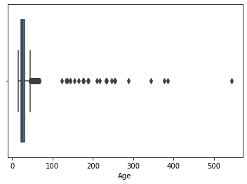

```python
sns.boxplot(x=data['Age'])
```

# DATA CLEANING

```python
data.groupby('Gender')['Age'].describe()
```

| Gender | count | mean | std | min | 25% | 50% | 75% | max |
| --- | --- | --- | --- | --- | --- | --- | --- | --- |
| F | 16309.0 | 26.915752 | 8.148578 | 15.0 | 22.0 | 25.0 | 31.0 | 377.0 |
| M | 5821.0 | 28.317299 | 15.599139 | 15.0 | 22.0 | 25.0 | 31.0 | 544.0 |
| TG | 1.0 | 36.000000 | NaN | 36.0 | 36.0 | 36.0 | 36.0 | 36.0 |

```python
#replace the outliers ages for males and females in the dataset with mean of ages of males and feamles respectively
data.loc[(data['Age']>=100) & (data['Gender']=='F'),'Age']=26
data.loc[(data['Age']>=100)&(data['Gender']=='M'),'Age']=28
```

```python
data['Age'].describe()
```

```
count    22131.000000
mean        27.050698
std          7.481802
min         15.000000
25%         22.000000
50%         25.000000
75%         31.000000
max         68.000000
Name: Age, dtype: float64
```

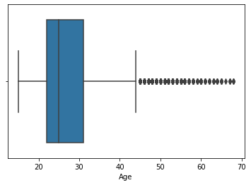

```python
sns.boxplot(x=data.Age)
```

```python
data1=data
```

```python
data['FacilityType'].replace('DICE','dice',inplace=True)
data['FacilityType'].replace('Public ','Public',inplace=True)
```

```python
np.unique(data['FacilityType'].values)
```

```
array(['Dice', 'Private', 'Public', 'dice'], dtype=object)
```

```python
data['FacilityType'].replace('dice','Dice',inplace=True)
```

```python
np.unique(data['FacilityType'].values)
```

```
array(['Dice', 'Private', 'Public'], dtype=object)
```

# DATA ANALYSIS

```python
#distribution of gender
data['Gender'].value_counts()
```

```
F     16309
M      5821
TG        1
Name: Gender, dtype: int64
```

```python
#percentage of distribution of gender
data['Gender'].value_counts(normalize=True)*100
```

```
F     73.693010
M     26.302472
TG     0.004519
Name: Gender, dtype: float64
```

```python
# gender distribution by county
pd.crosstab(data['Gender'],data['CountyOfBirth'])
```

| CountyOfBirth Gender | Baringo | Bomet | Bungoma | Busia | Elgeyo Marakwet | Embu | Garissa | Homa Bay | Isiolo | Kajiado | ... | Taita Taveta | Tana River | Tharaka Nithi | Trans Nzoia | Turkana | Uasin Gishu | Unknown | Vihiga | Wajir | West Pokot |
| --- | --- | --- | --- | --- | --- | --- | --- | --- | --- | --- | --- | --- | --- | --- | --- | --- | --- | --- | --- | --- | --- |
| F | 15 | 23 | 144 | 132 | 13 | 80 | 9 | 491 | 5 | 28 | ... | 260 | 6 | 4 | 29 | 1 | 33 | 2551 | 121 | 3 | 2 |
| M | 11 | 13 | 101 | 97 | 9 | 43 | 3 | 152 | 6 | 19 | ... | 18 | 2 | 2 | 18 | 3 | 14 | 570 | 74 | 1 | 0 |
| TG | 0 | 0 | 0 | 0 | 0 | 0 | 0 | 0 | 0 | 0 | ... | 0 | 0 | 0 | 0 | 0 | 0 | 0 | 0 | 0 | 0 |

3 rows × 48 columns

```python
gender_county=pd.crosstab(data['Gender'],data['CountyOfBirth'])
excel_path=("C:\\Users\\acer\\Downloads\\gender_by_county.xlsx")
gender_county.to_excel(excel_path)
```

```python
import matplotlib.pyplot as plt
```

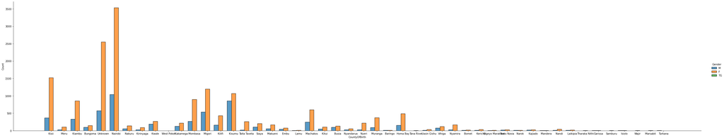

```python
plt.figure(figsize=(10,6))
sns.displot(data,x='CountyOfBirth',hue='Gender',multiple='dodge',height=8,aspect=5)
plt.show()
```

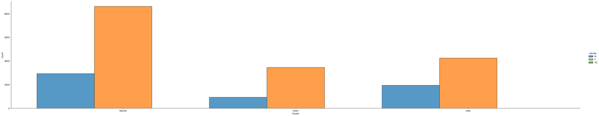

```python
sns.displot(data,x='Cluster',hue='Gender',multiple='dodge',height=8,aspect=5)
```

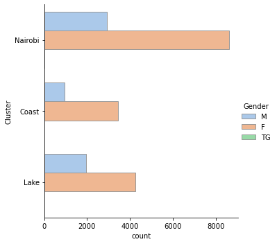

```python
sns.catplot(data=data, y="Cluster", hue="Gender", kind="count",palette="pastel", edgecolor=".6")
```

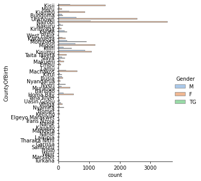

```python
sns.catplot(data=data, y="CountyOfBirth", hue="Gender", kind="count",palette="pastel", edgecolor=".6")
# Save the plot as an image file
plt.savefig('plot.png', dpi=300, bbox_inches='tight')
```

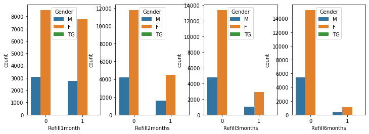

```python
_, axes = plt.subplots(nrows=1, ncols=4, figsize=(12, 4))
sns.countplot(x="Refill1month",hue='Gender', data=data, ax=axes[0])
sns.countplot(x="Refill2months",hue='Gender',data=data, ax=axes[1])
sns.countplot(x="Refill3months",hue='Gender',data=data, ax=axes[2])
sns.countplot(x="Refill6months",hue='Gender',data=data, ax=axes[3]);
```

```python
data['Refill1month'].value_counts()
```

```
0    11592
1    10539
Name: Refill1month, dtype: int64
```

```python
data['Refill2months'].value_counts()
```

```
0    16026
1     6105
Name: Refill2months, dtype: int64
```

```python
data['Refill3months'].value_counts()
```

```
0    18173
1     3958
Name: Refill3months, dtype: int64
```

```python
data['Refill6months'].value_counts()
```

```
0    20672
1     1459
Name: Refill6months, dtype: int64
```

```python
#data[(data['Refill1month']==1) & (data['Refill2months']==1) & (data['Refill3months']==1) & (data['Refill6months']==1)].value_counts()
```

```python
# total number of persons who consistently refilled their drugs
data[(data['Refill1month']==1) & (data['Refill2months']==1) & (data['Refill3months']==1) & (data['Refill6months']==1)]['Gender'].value_counts()
```

```
F    1073
M     386
Name: Gender, dtype: int64
```

```python
print('the percent of women who consistently refilled their drugs',1073/16309*100)
print('the percent of men who consistently refilled their drugs',386/5821*100)
```

```
the percent of women who consistently refilled their drugs 6.579189404623214
the percent of men who consistently refilled their drugs 6.631163030407146
```

For every 15 men enrolled in the program 1 man consistently refill their drugs to the entirity of the program. For every 15 women enrolled in the program 1 woman consistently refill their drugs to the entirity of the program.

```python
data[(data['Refill1month']==1) & (data['Refill2months']==1) & (data['Refill3months']==1) & (data['Refill6months']==1)]['CountyOfBirth'].value_counts()
```

```
Kisii              289
Kisumu             179
Mombasa            175
Unknown            143
Nairobi            108
Migori              88
Kilifi              86
Homa Bay            55
Machakos            47
Kiambu              45
Taita Taveta        23
Kwale               22
Kakamega            21
Bungoma             20
Muranga             20
Nyamira             17
Siaya               14
Makueni             14
Busia               13
Nyeri               10
Meru                 9
Vihiga               9
Kitui                7
Nakuru               7
Nyandarua            5
Kirinyaga            5
Trans Nzoia          4
Kajiado              3
Embu                 3
Nandi                3
Kericho              2
Isiolo               2
Baringo              2
Mandera              2
Uasin Gishu          2
Lamu                 1
Narok                1
Laikipia             1
Marsabit             1
Elgeyo Marakwet      1
Name: CountyOfBirth, dtype: int64
```

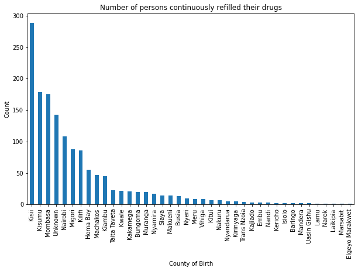

```python
# number of persons who continuously refilled their drugs
filtered_data = data[(data['Refill1month'] == 1) & (data['Refill2months'] == 1) & (data['Refill3months'] == 1) & (data['Refill6months'] == 1)]

# Plot the value counts of 'CountyOfBirth'
plt.figure(figsize=(10, 6))
filtered_data['CountyOfBirth'].value_counts().plot(kind='bar')
plt.xlabel('County of Birth')
plt.ylabel('Count')
plt.title('Number of persons continuously refilled their drugs')
plt.show()
```

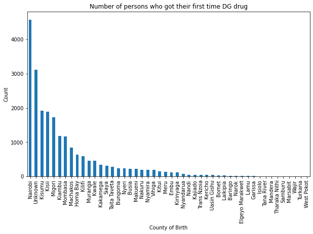

```python
# distribution of first time pick up of drugs across county of birth
recruited_pt=data[data['Received_DP']==1]
plt.figure(figsize=(10, 6))
recruited_pt['CountyOfBirth'].value_counts().plot(kind='bar')
plt.xlabel('County of Birth')
plt.ylabel('Count')
plt.title('Number of persons who got their first time DG drug')
plt.show()
```

```python
pd.crosstab(data['FacilityType'],data['Received_DP'])
```

| Received_DP FacilityType | 1 |
| --- | --- |
| Dice | 15477 |
| Private | 1085 |
| Public | 5569 |

```python
filtered_data['FacilityType'].value_counts()
```

```
Dice       1037
Public      377
Private      45
Name: FacilityType, dtype: int64
```

For every 24 persons enrolled in the program in facility type private 1 patient refills their drugs consistetly. For every 15 persons enrolled in the program in facility type dice 1 patient refills their drugs consistetly. For every 15 persons enrolled in the program in facility type public 1 patient refills their drugs consistetly.

```python
pd.crosstab(data['received_counseling'],data['Received_DP'])
```

| Received_DP received_counseling | 1 |
| --- | --- |
| 0 | 10600 |
| 1 | 11531 |

```python
filtered_data['received_counseling'].value_counts()
```

```
1    1312
0     147
Name: received_counseling, dtype: int64
```

Only 1% of individuals who did not receive counselling consistently refill their drugs. 11% of individuals who received counselling consistently refill their drugs. 89.9% of individuals who consistently refilled their drugs received counselling as compared to 52.1% of individuals who received counselling in the first administration.

```python
data.columns
```

```
Index(['clientsid', 'Gender', 'CountyOfBirth', 'Age', 'EntryPoint',
       'ReferredOrTransferredFrom', 'InitialVisitDate', 'BP', 'Weight_',
       'Height', 'SignOfSti', 'Lmp', 'Cluster', 'FacilityType', 'Received_DP',
       'Refill1month', 'Refill2months', 'Refill3months', 'Refill6months',
       'received_counseling'],
      dtype='object')
```

```python
from scipy import stats
```

```python
# Extract the columns you want to analyze
columns_to_analyze = ['received_counseling', 'Refill6months']

# Create DataFrames for the two groups
first_administration = data[columns_to_analyze]
continuous_participants = filtered_data[columns_to_analyze]
```

```python
first_administration.dtypes
```

```
received_counseling    int64
Refill6months          int64
dtype: object
```

```python
continuous_participants.dtypes
```

```
received_counseling    int64
Refill6months          int64
dtype: object
```

```python
# test for significant statistical difference between participants who recieved counsel and those who did not in refilling their drugs consistently.
# Null hypothesis; there is no impact of counseling in consistent refill of DP pills among participants
# Alternative hypothesis; there is imoact of counseling in consistent refill of DP pills among participants
import scipy.stats.distributions as dist

def z_test(x1,x2,n1,n2,two_tailed=True):
    avg_p=(x1+x2)/(n1+n2)
    z_val=(x1/n1-x2/n2)/np.sqrt(avg_p*(1-avg_p)*(1/n1 + 1/n2))
    z_prob= dist.norm.cdf(-np.abs(z_val))

    if two_tailed:
        return z_val,2*z_prob
    else:
        return z_val,z_prob
```

```python
z_test(11531,1312,22131,1458,two_tailed=True)
```

```
(-28.133293931762307, 3.8369888460968653e-174)
```

```python
from scipy.stats import chi2_contingency

contingency_table = [[1312, 10219],
                     [147, 10453]]

chi2, p, _, _ = chi2_contingency(contingency_table)
print("Chi-squared statistic:", chi2)
print("p-value:", p)
```

```
Chi-squared statistic: 893.6897646376335
p-value: 2.309911851063071e-196
```

the p value is less than 0.05 thus we can reject the null hypothesis and conclude that counseling has impact on refilling pills.

We conclude that the is a significant difference between the participants who received counseling and those who did not in refilling DP consistently. Therefore , counseling had a huge imoact in DP refills by participants.

# RECOMMENDATION

Based on the analysis, the JHG should encourage the population to attend counseling to dispel misconceptions, myths and misinformation. In addition educate them on the importance, effectiveness of the DG drug for sexual reproductive health. Given that counseling is an engaging activity between professionals and the target population other strategies may complement this such as practical management tools (e.g reminders).

# EVALUATING INTERVENTIONS

HG decides to implement the intervention/improvement you suggested (i.e., from your answer in d on the previous slide). After one year, you see that the number of patients receiving DP has increased by 25% while those continuously refilling DP every month has increased by 30%.

Can you say that the intervention/improvement caused the increase in DP use by 25% and continuous use by 30%? Explain why or why not.

The difference observed after intervention is as a result of the intervention. There was increase in use of DP and continuous use after the intervention. After comparison between the first phase without the intervention and second phase after intervention.

Can you tell us what would be a better way (if at all) to assess the effectiveness of your intervention?

Use a randomised control trial research design. Through which I will split the sample in a treatment group and contol group. the treatment group will receive the recommended intreventions while the control group will not through a period of 6 months. The data collected will then be analysed using analysis of variance to assess the effectiveness of the treatment, which are the interventions recommended.